# laboratorio 4

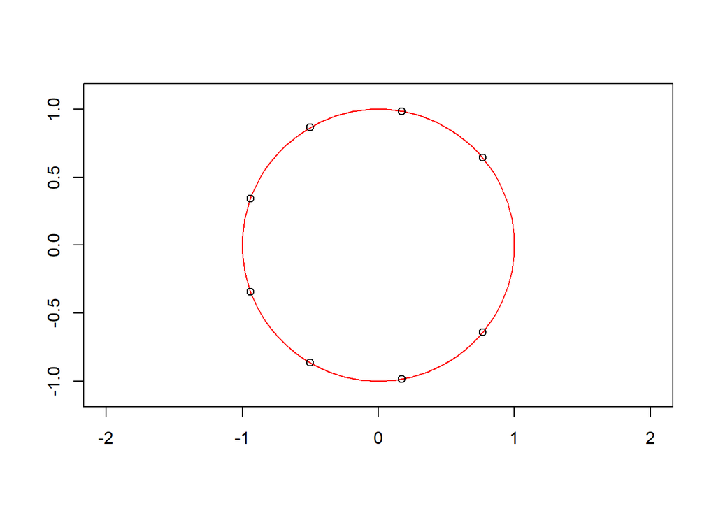

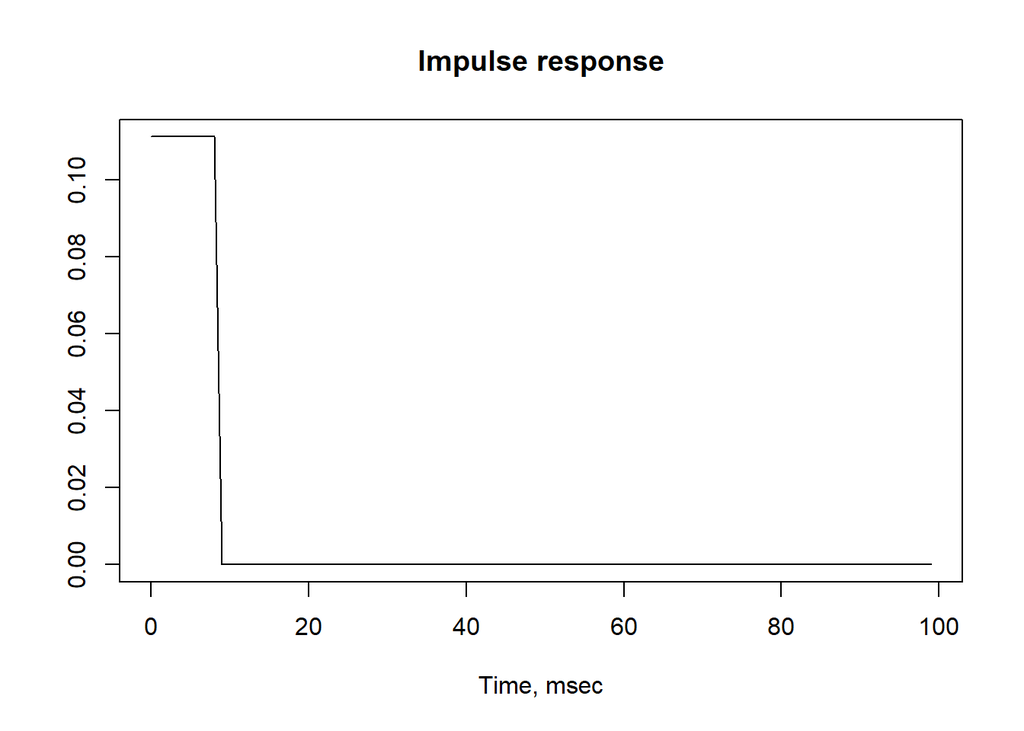

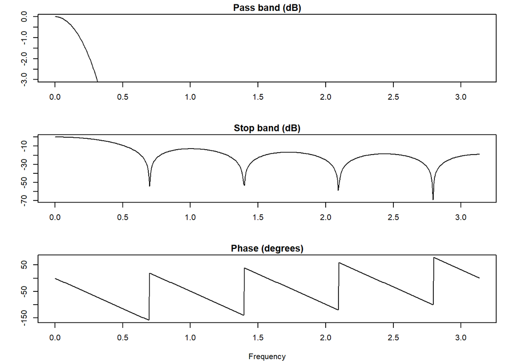

```r
peine(9)
```

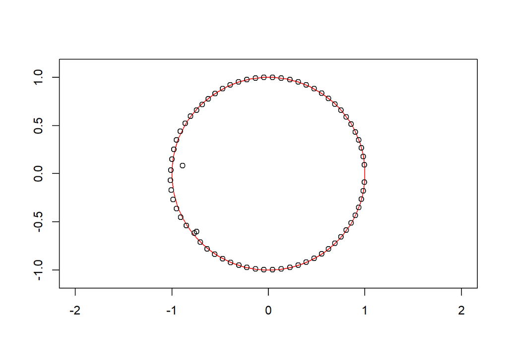

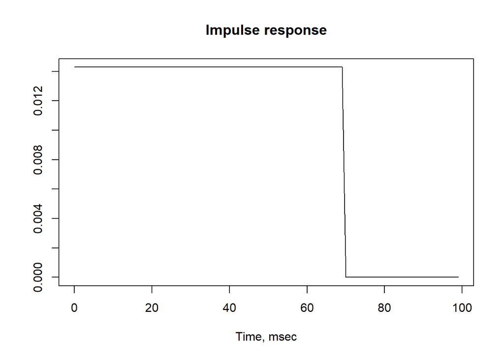

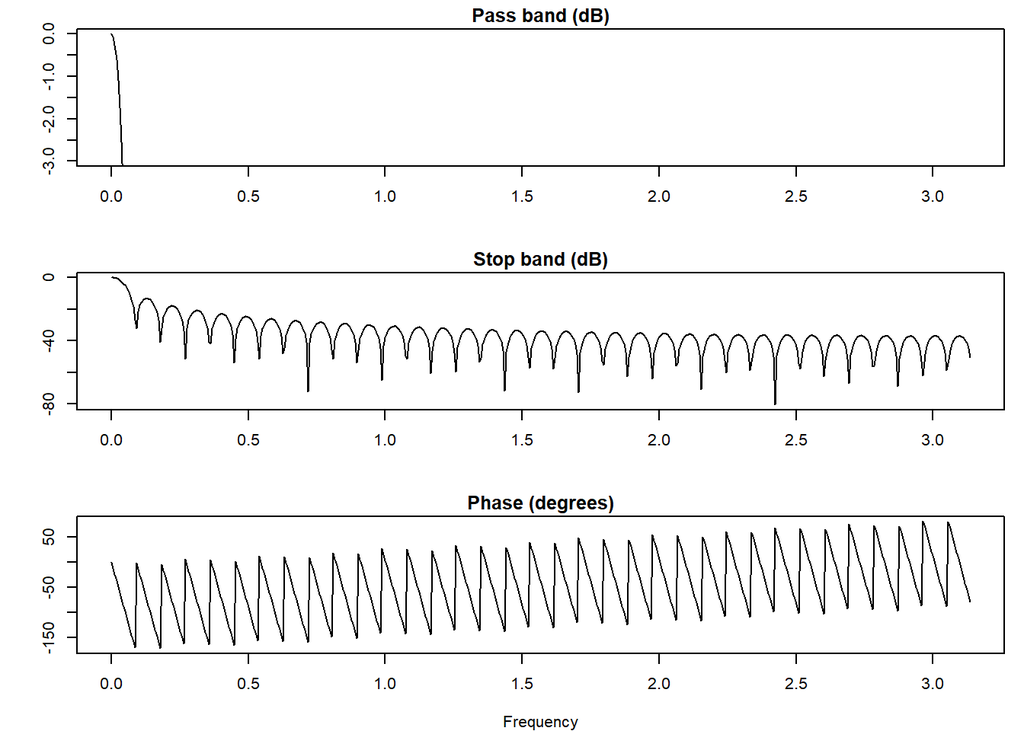

```r
peine(70) # tantos puntos como soluciones posibles del polinimo, no hay polos porque el denominador se anula
```

¿Qué tienen de especial? ¿Qué ocurre en los ceros de H(z)?

Tiene tantos puntos como soluciones posibles del polinimo que graficadas se encuentran igualmente espaciadas alrededor de un círculo en el plano complejo; esos son los ceros de la función de transferencia. No hay polos porque el denominador se anula cuando $z^{K}=0$.

## 1.2 Eliminar ruido

A continuación, se implementará una aplicación práctica en Ingeniería Biomédica, la eliminación del ruido de red en un electrocardiograma (ECG). Para ello utiliza el fichero ecg.mat que contiene un ECG contaminado por ruido de 50 Hz. Diseña un sistema digital para eliminar dicha interferencia mediante un análisis de polos/zeros de la Transformada Z (el ECG se ha adquirido con una frecuencia de muestreo de ECG de 1000 Hz). Implementa diferentes alternativas para eliminar este ruido.

Importamos datos:

```r
library(rmatio)
```

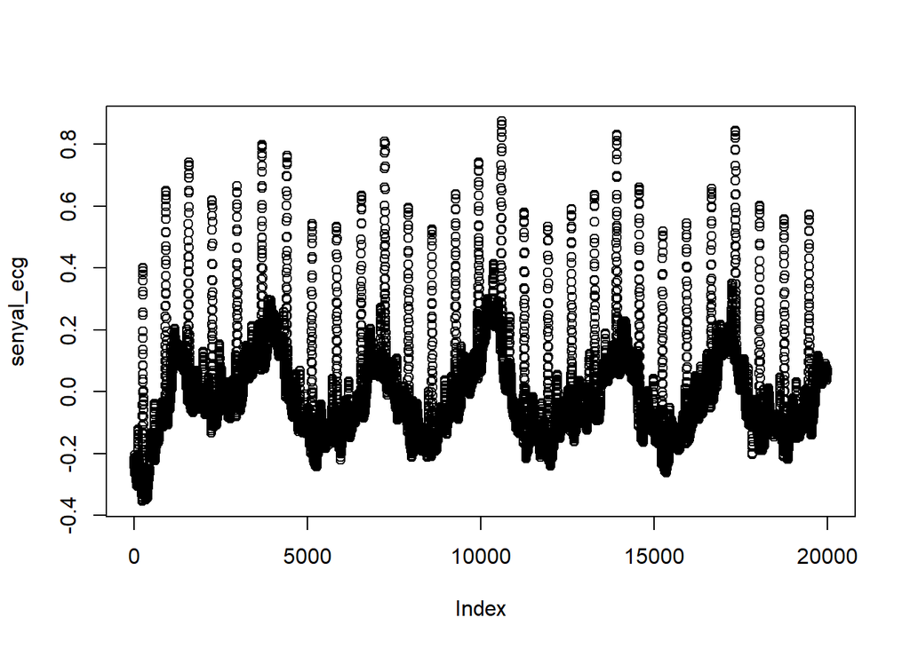

```r
ecg <- read.mat("ecg.mat") # contaminado por ruido de 50 Hz.
senyal_ecg <- ecg$ecg # tomamos variables ecg del dataframe
plot(senyal_ecg) # representamos señal original
```

Definimos frecuencias:

```r
muestreo = 1000
ruido = 50
```

Frecuencia angular:

```r
w = (ruido/muestreo) * 2*pi
```

Definimos valores:

```r
ceros = 1
polos = 1-(2*pi)/100
```

Definimos vectores para polos y ceros

```r
x1 <- c(1,(-2)*ceros*cos(w),ceros**2)
x2 <- c(1,(-2)*polos*cos(w),polos**2)
```

Representamos la señal en el plano z, la respuesta impulsional y la respuesta en frecuencias:

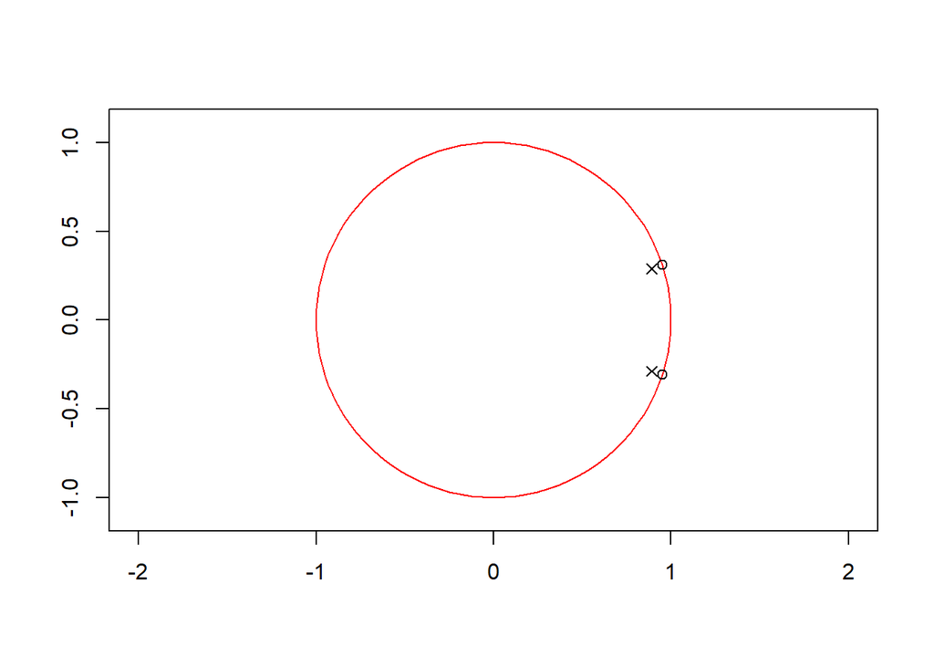

```r
zplane(x1,x2)
```

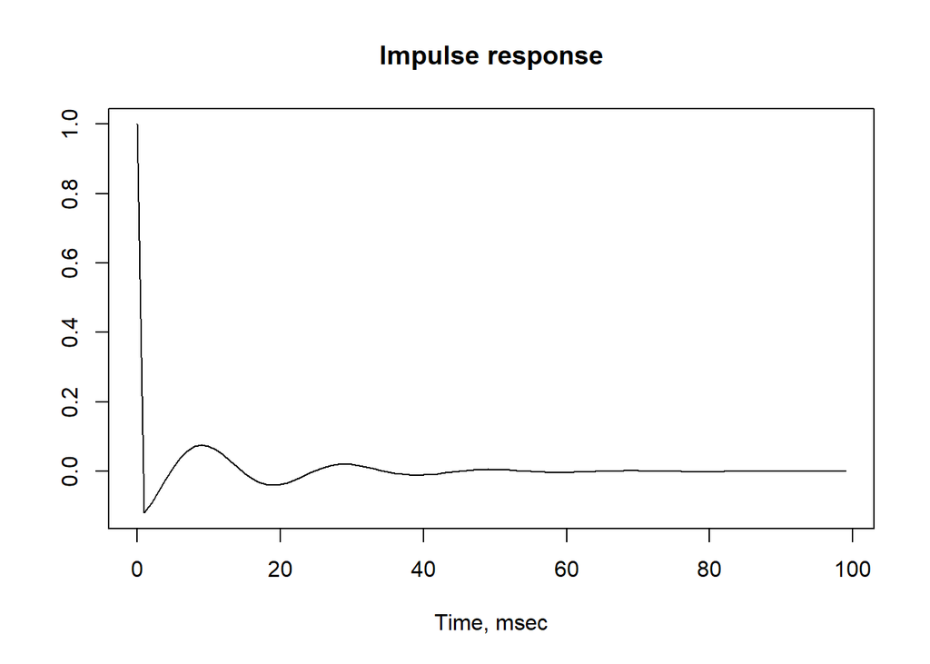

```r
impz(x1,x2,100)
```

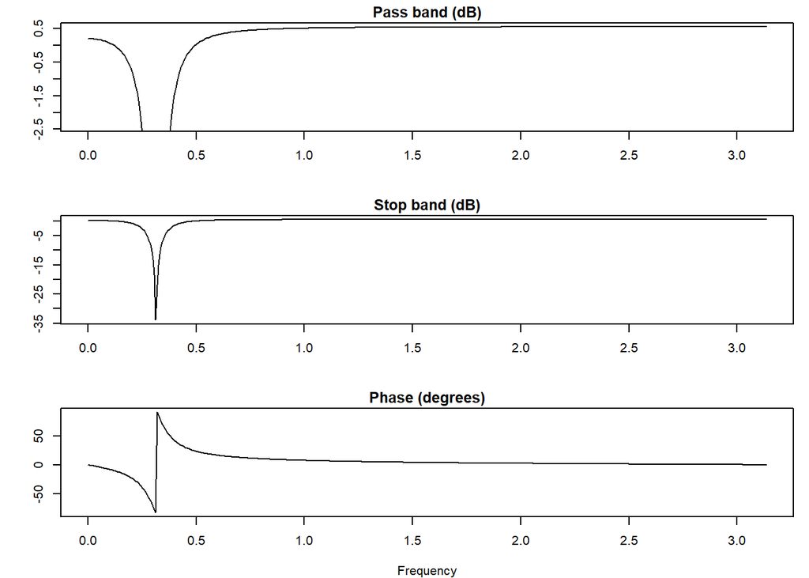

```r
freqz(x1,x2)
```

Aplicamos un primer filtro a la señal ECG original:

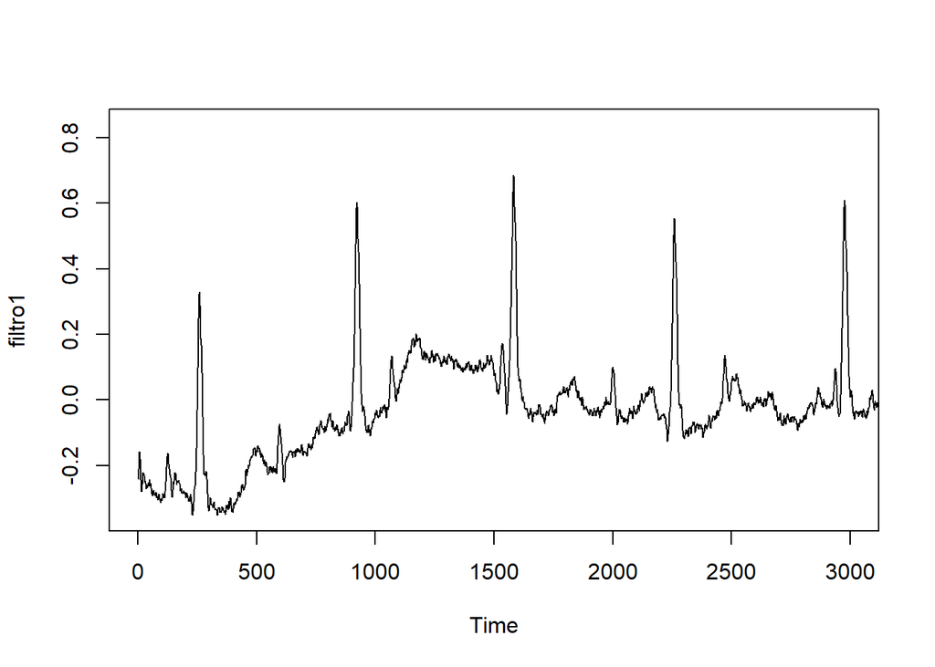

```r
filtro1 <- signal::filter(x1,x2,senyal_ecg) # señal ecg
plot(filtro1,xlim=c(0,3000))
```

Podemos ver que la señal se ha ‘limpiado’ tras aplicar este primer filtro. Ahora, probamos diferentes valores de $\mu$ para ajustar la señal.

Implementa diferentes valores para $\mu$:

```r
filtros <- function(m,filtro){
  v1 <- c(1,-1)
  v2 <- c(1,-m)
  filtro <- filter(v1,v2,filtro) # filtramos
  zplane(v1,v2)
  impz(v1,v2,100)
  freqz(v1,v2)
  plot(filtro,xlim = c(0,3000))} #representamos el resultado
```

Analizamos el resultado para diferentes filtros:

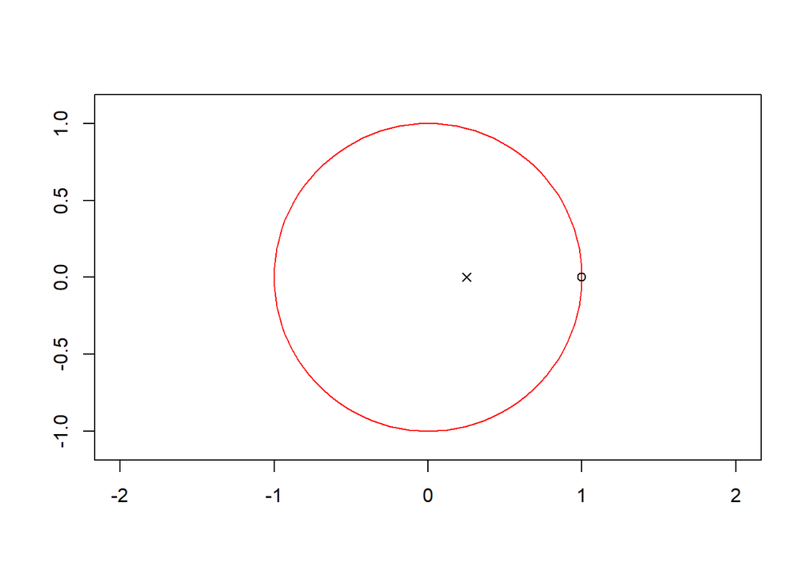

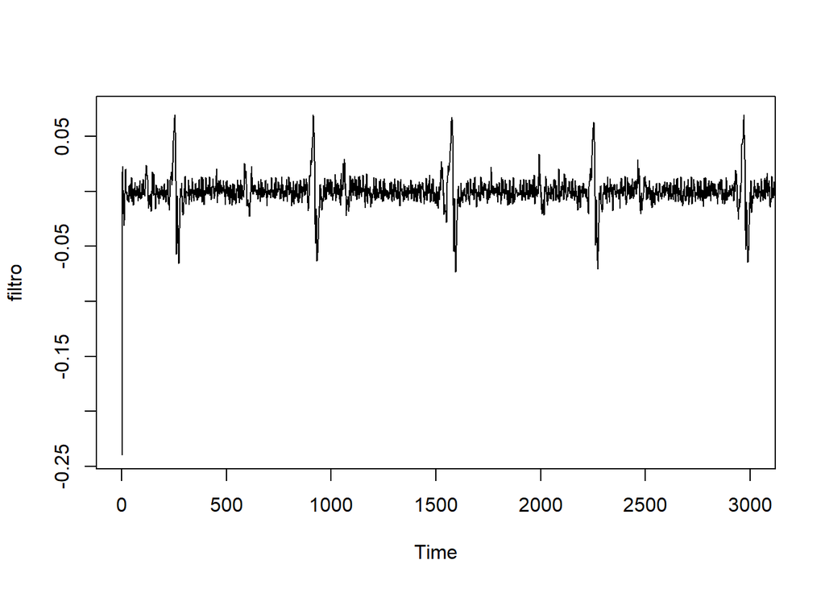

```r
filtros(0.25,filtro1)
```

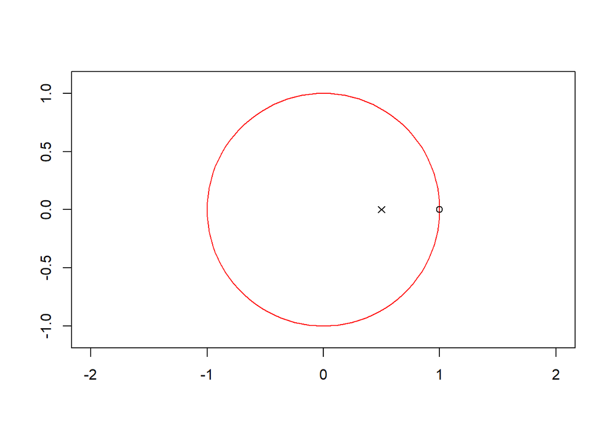

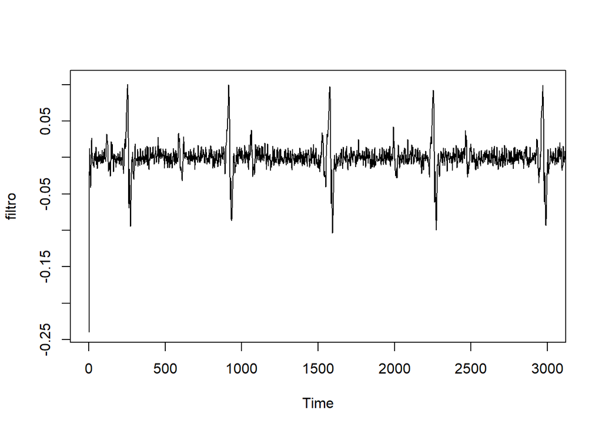

```r
filtros(0.5,filtro1)
```

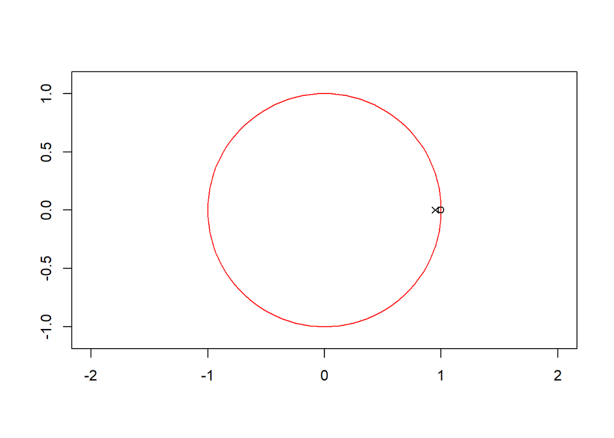

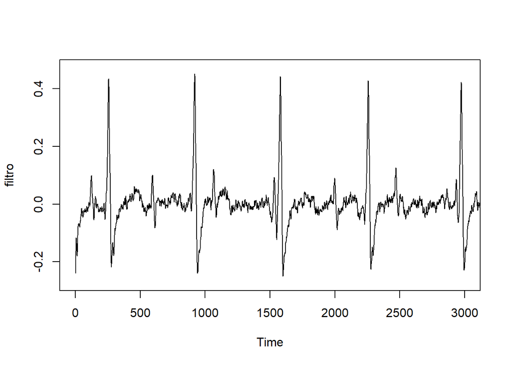

```r
filtros(0.95,filtro1)
```

Concluimos que aumentar el valor de $\mu$ mejora la resolución de la señal.